# Companion Notebook for An agent-based model to investigate the effects of urban segregation around the clock on inequalities in health behaviour

Clémentine Cottineau-Mugadza, Julien Perret, Romain Reuillon, Sébastien Rey-Coyrehourcq, Julie Vallée

2025-10-07

# Libraries

```r
library(tidyverse)
library(reshape2)
library(sf)
library(spdep)
library(tmap)
library(cowplot)
library(here)
library(OasisR) ## package OK for version R.4.4.3 (windows)
```

# Synthetic population - H24 library (section 2.1)

Import data for synthetic population located in ‘night’ cell `pop0`, in ‘day’ cell `pop1` and in ‘evening’ cell `pop2`

```r
pop_0 <- st_read( "data/population.gpkg",
              layer="Population_0", quiet = TRUE)
pop_1 <- st_read("data/population.gpkg",
                  layer="Population_1", quiet = TRUE)
pop_2 <- st_read("data/population.gpkg",
                  layer="Population_2", quiet = TRUE)
```

Create new colums : gender (2 groups) ; Age (3 groups); Educ (3 Groups)

```r
pop_0 <- pop_0 %>%
  rowwise() %>%
  mutate(
    men =  sum(across(starts_with('pop_1'))),
    women = sum(across(starts_with('pop_2'))),
    pop = men + women,

    age1 = sum(across(starts_with(c('pop_1_1', 'pop_2_1')))),
    age2 = sum(across(starts_with(c('pop_1_2', 'pop_2_2')))),
    age3 = sum(across(starts_with(c('pop_1_3', 'pop_2_3')))),

    educ1 = sum(across(ends_with('_1'))),
    educ2 = sum(across(ends_with('_2'))),
    educ3 = sum(across(ends_with('_3'))),

    pct_educ3 = (educ3 / pop) * 100,
    pct_age3 = (age3 / pop) * 100,
    pct_women = (women / pop) * 100
    )

pop_1 <- pop_1 %>%
  rowwise() %>%
  mutate(
    men =  sum(across(starts_with('pop_1'))),
    women = sum(across(starts_with('pop_2'))),

    age1 = sum(across(starts_with(c('pop_1_1', 'pop_2_1')))),
    age2 = sum(across(starts_with(c('pop_1_2', 'pop_2_2')))),
    age3 = sum(across(starts_with(c('pop_1_3', 'pop_2_3')))),

    educ1 = sum(across(ends_with('_1'))),
    educ2 = sum(across(ends_with('_2'))),
    educ3 = sum(across(ends_with('_3')))
  )

pop_2 <- pop_2 %>%
  rowwise() %>%
  mutate(
    men =  sum(across(starts_with('pop_1'))),
    women = sum(across(starts_with('pop_2'))),

    age1 = sum(across(starts_with(c('pop_1_1', 'pop_2_1')))),
    age2 = sum(across(starts_with(c('pop_1_2', 'pop_2_2')))),
    age3 = sum(across(starts_with(c('pop_1_3', 'pop_2_3')))),

    educ1 = sum(across(ends_with('_1'))),
    educ2 = sum(across(ends_with('_2'))),
    educ3 = sum(across(ends_with('_3')))
  )
```

## Distribution of the synthetic population in night cells in the Paris Region (Figure 1)

Total Population density

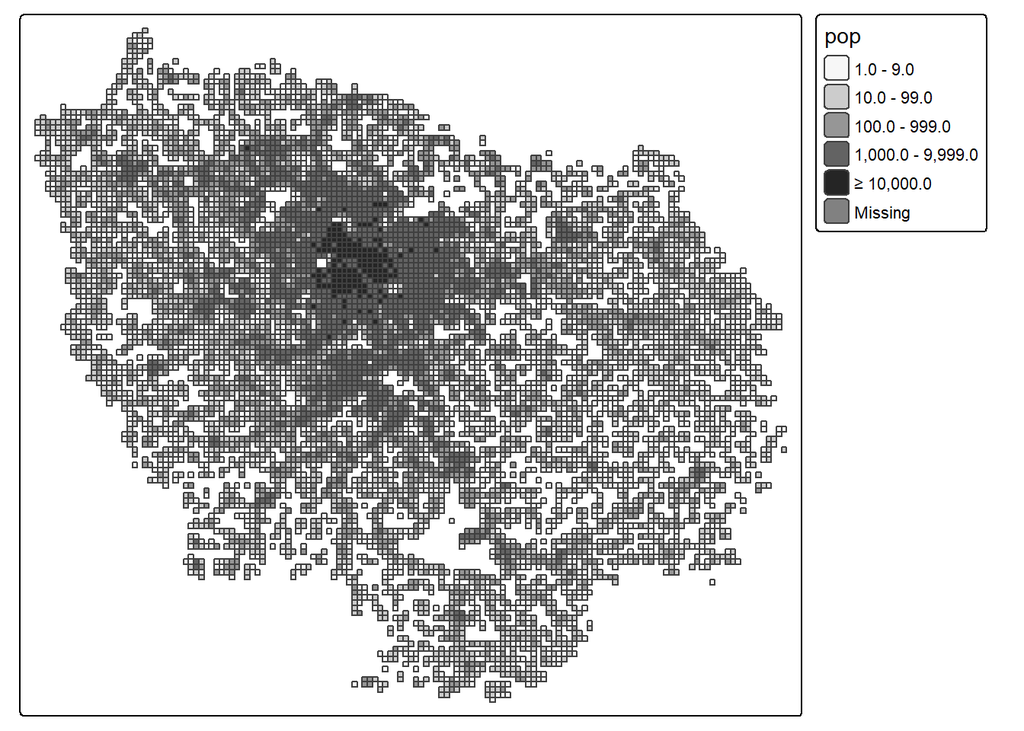

```r
bks_pop <- c(1, 10, 100, 1000, 10000, Inf)

tm_shape(pop_0) + tm_fill(col="pop", style="fixed",
                       breaks = bks_pop, palette="Greys") +
  tm_legend(outside=TRUE)
```

Proportion of people with 2+ years of higher education

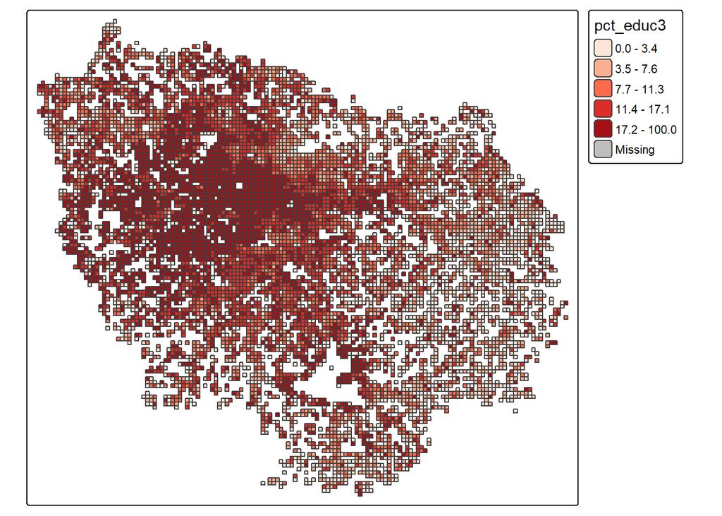

```r
bks_edu <- c(0, 3.5, 7.7, 11.4, 17.2, 100)


tm_shape(pop_0) + tm_fill(col="pct_educ3", style="fixed",
                       breaks = bks_edu, palette="Reds") +
  tm_legend(outside=TRUE)
```

Proportion of people aged 60+

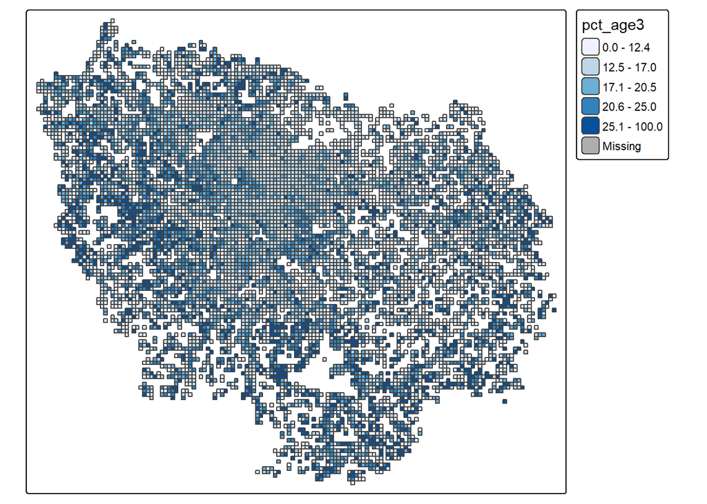

```r
bks_age <- c(0, 12.5, 17.1, 20.6, 25.1, 100)


tm_shape(pop_0) + tm_fill(col="pct_age3", style="fixed",
                       breaks = bks_age, palette="Blues") +
  tm_legend(outside=TRUE)
```

Proportion of women

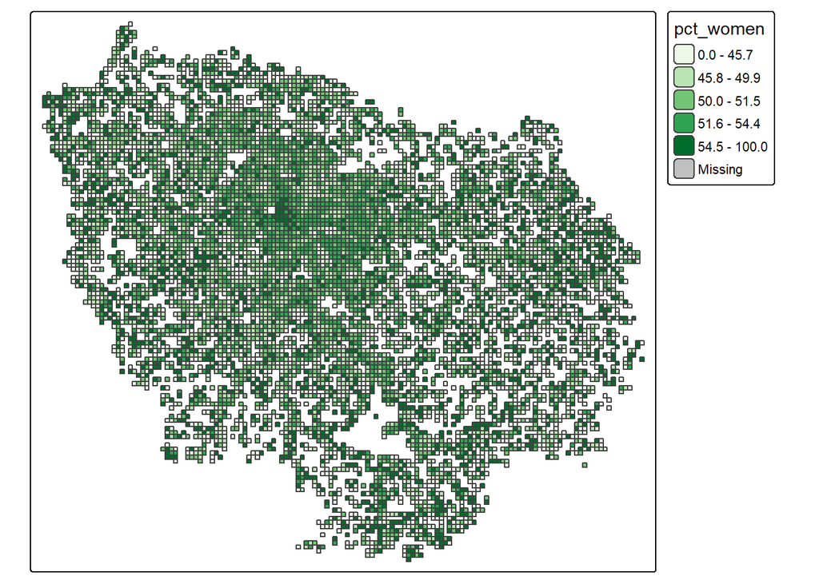

```r
bks_sex <- c(0, 45.8, 50, 51.6, 54.5, 100)


tm_shape(pop_0) + tm_fill(col="pct_women", style="fixed",
                       breaks = bks_sex, palette="Greens") +
  tm_legend(outside=TRUE)
```

### Duncan Dissimilarity Index (Appendix 3)

Duncan’s segregation index is one-group form of dissimilarity index DI and measures the unevenness of a group distribution compared to the rest of the population. It can be interpreted as the share of the group that would have to move to achieve an even distribution compared to the rest of the population. You should not include a column with total population, because this will be interpreted as a group.

In night cells

```r
dfpop_0 <- pop_0 %>% st_drop_geometry()

pop_0_Duncan_18categ<- as.data.frame(ISDuncan(dfpop_0[,2:19]))
colnames(pop_0_Duncan_18categ)[1] <- "Duncan_night"
rownames(pop_0_Duncan_18categ) <- paste (colnames(dfpop_0[ , 2:19]))

pop_0_Duncan_sex<- as.data.frame(ISDuncan(dfpop_0[,20:21]))
colnames(pop_0_Duncan_sex)[1] <- "Duncan_night"
rownames(pop_0_Duncan_sex) <- paste (colnames(dfpop_0[ , 20:21]))

pop_0_Duncan_age<- as.data.frame(ISDuncan(dfpop_0[,22:24]))
colnames(pop_0_Duncan_age)[1] <- "Duncan_night"
rownames(pop_0_Duncan_age) <- paste (colnames(dfpop_0[ , 22:24]))

pop_0_Duncan_educ<- as.data.frame(ISDuncan(dfpop_0[,25:27]))
colnames(pop_0_Duncan_educ)[1] <- "Duncan_night"
rownames(pop_0_Duncan_educ) <- paste (colnames(dfpop_0[ , 25:27]))

pop_0_all_Duncan <- bind_rows(pop_0_Duncan_18categ, pop_0_Duncan_sex, pop_0_Duncan_age, pop_0_Duncan_educ)

pop_0_all_Duncan_round <- pop_0_all_Duncan %>% mutate(across(starts_with("Duncan"), round, 3))
```

In day cells

```r
dfpop_1 <- pop_1 %>% st_drop_geometry()

pop_1_Duncan_18categ<- as.data.frame(ISDuncan(dfpop_1[,2:19]))
colnames(pop_1_Duncan_18categ)[1] <- "Duncan_day"
rownames(pop_1_Duncan_18categ) <- paste (colnames(dfpop_1[ , 2:19]))

pop_1_Duncan_sex<- as.data.frame(ISDuncan(dfpop_1[,20:21]))
colnames(pop_1_Duncan_sex)[1] <- "Duncan_day"
rownames(pop_1_Duncan_sex) <- paste (colnames(dfpop_1[ , 20:21]))

pop_1_Duncan_age<- as.data.frame(ISDuncan(dfpop_1[,22:24]))
colnames(pop_1_Duncan_age)[1] <- "Duncan_day"
rownames(pop_1_Duncan_age) <- paste (colnames(dfpop_1[ , 22:24]))

pop_1_Duncan_educ<- as.data.frame(ISDuncan(dfpop_1[,25:27]))
colnames(pop_1_Duncan_educ)[1] <- "Duncan_day"
rownames(pop_1_Duncan_educ) <- paste (colnames(dfpop_1[ , 25:27]))

pop_1_all_Duncan <- bind_rows(pop_1_Duncan_18categ, pop_1_Duncan_sex, pop_1_Duncan_age, pop_1_Duncan_educ)

pop_1_all_Duncan_round <- pop_1_all_Duncan %>% mutate(across(starts_with("Duncan"), round, 3))
```

In evening cells

```r
dfpop_2 <- pop_2 %>% st_drop_geometry()

pop_2_Duncan_18categ<- as.data.frame(ISDuncan(dfpop_2[,2:19]))
colnames(pop_2_Duncan_18categ)[1] <- "Duncan_evening"
rownames(pop_2_Duncan_18categ) <- paste (colnames(dfpop_2[ , 2:19]))

pop_2_Duncan_sex<- as.data.frame(ISDuncan(dfpop_2[,20:21]))
colnames(pop_2_Duncan_sex)[1] <- "Duncan_evening"
rownames(pop_2_Duncan_sex) <- paste (colnames(dfpop_2[ , 20:21]))

pop_2_Duncan_age<- as.data.frame(ISDuncan(dfpop_2[,22:24]))
colnames(pop_2_Duncan_age)[1] <- "Duncan_evening"
rownames(pop_2_Duncan_age) <- paste (colnames(dfpop_2[ , 22:24]))

pop_2_Duncan_educ<- as.data.frame(ISDuncan(dfpop_2[,25:27]))
colnames(pop_2_Duncan_educ)[1] <- "Duncan_evening"
rownames(pop_2_Duncan_educ) <- paste (colnames(dfpop_2[ , 25:27]))

pop_2_all_Duncan <- bind_rows(pop_2_Duncan_18categ, pop_2_Duncan_sex, pop_2_Duncan_age, pop_2_Duncan_educ)

pop_2_all_Duncan_round <- pop_2_all_Duncan %>% mutate(across(starts_with("Duncan"), round, 3))
```

Build table

```r
pop_all_Duncan_round <- bind_cols(pop_0_all_Duncan_round, pop_1_all_Duncan_round, pop_2_all_Duncan_round)
pop_all_Duncan_round
```

```
##           Duncan_night Duncan_day Duncan_evening
## pop_1_1_1        0.152      0.549          0.548
## pop_1_1_2        0.082      0.442          0.423
## pop_1_1_3        0.257      0.570          0.550
## pop_1_2_1        0.182      0.394          0.372
## pop_1_2_2        0.091      0.391          0.345
## pop_1_2_3        0.274      0.437          0.386
## pop_1_3_1        0.184      0.564          0.553
## pop_1_3_2        0.121      0.665          0.698
## pop_1_3_3        0.284      0.528          0.560
## pop_2_1_1        0.138      0.558          0.559
## pop_2_1_2        0.088      0.445          0.396
## pop_2_1_3        0.275      0.492          0.493
## pop_2_2_1        0.160      0.371          0.362
## pop_2_2_2        0.086      0.364          0.320
## pop_2_2_3        0.263      0.375          0.373
## pop_2_3_1        0.150      0.501          0.481
## pop_2_3_2        0.131      0.573          0.592
## pop_2_3_3        0.295      0.570          0.605
## men              0.033      0.230          0.159
## women            0.033      0.230          0.159
## age1             0.076      0.297          0.262
## age2             0.052      0.280          0.224
## age3             0.095      0.370          0.345
## educ1            0.241      0.349          0.361
## educ2            0.067      0.252          0.236
## educ3            0.322      0.358          0.404
```

### Moran’s index of spatial autocorrelation (Appendix 3)

In night cells

```r
dfpop_0_prop <- dfpop_0/dfpop_0$pop
pop_0_geom <- pop_0[, -1:-28]
pop_0_prop <- bind_cols(pop_0_geom, dfpop_0_prop)

nb0 <- poly2nb(pop_0_prop, queen=TRUE)
lw0 <- nb2listw(nb0, style="W", zero.policy=TRUE)

list <- colnames(dfpop_0_prop[,2:27])
pop_0_moran <- data.frame(matrix(ncol = 2))
colnames(pop_0_moran) <- c("pop_night_IMoran" , "pop_night_Moranpvalue")

for (i in list)
{
  pop_0_i <- pop_0_prop[,i]
  colnames(pop_0_i)[1] ="ok"
  pop_0_moran[i, 1] <- moran.test(pop_0_i$ok, lw0, zero.policy=TRUE, alternative="greater") [3]
  pop_0_moran[i, 2] <- moran.test(pop_0_i$ok, lw0, zero.policy=TRUE, alternative="greater") [2]
}

pop_0_moran <- pop_0_moran[-1,] # Delete empty first line

pop_0_moran_round <- pop_0_moran %>% mutate(across(starts_with("pop"), round, 3))
pop_0_moran_round
```

```
##           pop_night_IMoran pop_night_Moranpvalue
## pop_1_1_1            0.022                 0.000
## pop_1_1_2            0.035                 0.000
## pop_1_1_3            0.069                 0.000
## pop_1_2_1            0.100                 0.000
## pop_1_2_2            0.003                 0.327
## pop_1_2_3            0.198                 0.000
## pop_1_3_1            0.027                 0.000
## pop_1_3_2            0.013                 0.026
## pop_1_3_3            0.068                 0.000
## pop_2_1_1            0.020                 0.002
## pop_2_1_2            0.040                 0.000
## pop_2_1_3            0.031                 0.000
## pop_2_2_1            0.066                 0.000
## pop_2_2_2            0.010                 0.074
## pop_2_2_3            0.110                 0.000
## pop_2_3_1            0.023                 0.000
## pop_2_3_2            0.029                 0.000
## pop_2_3_3            0.050                 0.000
## men                  0.018                 0.004
## women                0.018                 0.004
## age1                 0.076                 0.000
## age2                 0.026                 0.000
## age3                 0.068                 0.000
## educ1                0.303                 0.000
## educ2                0.071                 0.000
## educ3                0.367                 0.000
```

In day cells

```r
dfpop_1_prop <- dfpop_1/dfpop_1$pop
pop_1_geom <- pop_1[, -1:-28]
pop_1_prop <- bind_cols(pop_1_geom, dfpop_1_prop)

nb1 <- poly2nb(pop_1_prop, queen=TRUE)
lw1 <- nb2listw(nb1, style="W", zero.policy=TRUE)

list <- colnames(dfpop_1_prop[,2:27])

pop_1_moran <- data.frame(matrix(ncol = 2))
colnames(pop_1_moran) <- c( "pop_day_IMoran" , "pop_day_Moranpvalue")

for (i in list)
{
  pop_1_i <- pop_1_prop[,i]
  colnames(pop_1_i)[1] ="ok"
  pop_1_moran[i, 1] <- moran.test(pop_1_i$ok, lw1, zero.policy=TRUE, alternative="greater") [3]
  pop_1_moran[i, 2] <- moran.test(pop_1_i$ok, lw1, zero.policy=TRUE, alternative="greater") [2]
}

pop_1_moran <- pop_1_moran[-1,] # Delete empty first line

pop_1_moran_round <- pop_1_moran %>% mutate(across(starts_with("pop"), round, 3))
pop_1_moran_round
```

```
##           pop_day_IMoran pop_day_Moranpvalue
## pop_1_1_1          0.182                   0
## pop_1_1_2          0.197                   0
## pop_1_1_3          0.184                   0
## pop_1_2_1          0.085                   0
## pop_1_2_2          0.060                   0
## pop_1_2_3          0.062                   0
## pop_1_3_1          0.187                   0
## pop_1_3_2          0.331                   0
## pop_1_3_3          0.110                   0
## pop_2_1_1          0.189                   0
## pop_2_1_2          0.126                   0
## pop_2_1_3          0.104                   0
## pop_2_2_1          0.060                   0
## pop_2_2_2          0.036                   0
## pop_2_2_3          0.055                   0
## pop_2_3_1          0.086                   0
## pop_2_3_2          0.325                   0
## pop_2_3_3          0.225                   0
## men                0.150                   0
## women              0.150                   0
## age1               0.175                   0
## age2               0.239                   0
## age3               0.279                   0
## educ1              0.226                   0
## educ2              0.201                   0
## educ3              0.172                   0
```

In evening cells

```r
dfpop_2_prop <- dfpop_2/dfpop_2$pop
pop_2_geom <- pop_2[, -1:-28]
pop_2_prop <- bind_cols(pop_2_geom, dfpop_2_prop)

nb2 <- poly2nb(pop_2_prop, queen=TRUE)
lw2 <- nb2listw(nb2, style="W", zero.policy=TRUE)

list <- colnames(dfpop_2_prop[,2:27])

pop_2_moran <- data.frame(matrix(ncol = 2))
colnames(pop_2_moran) <- c( "pop_evening_IMoran" , "pop_evening_Moranpvalue")

for (i in list)
{
  pop_2_i <- pop_2_prop[,i]
  colnames(pop_2_i)[1] ="ok"
  pop_2_moran[i, 1] <- moran.test(pop_2_i$ok, lw2, zero.policy=TRUE, alternative="greater") [3]
  pop_2_moran[i, 2] <- moran.test(pop_2_i$ok, lw2, zero.policy=TRUE, alternative="greater") [2]
}

pop_2_moran <- pop_2_moran[-1,] # Delete empty first line

pop_2_moran_round <- pop_2_moran %>% mutate(across(starts_with("pop"), round, 3))
pop_2_moran_round
```

```
##           pop_evening_IMoran pop_evening_Moranpvalue
## pop_1_1_1              0.125                       0
## pop_1_1_2              0.193                       0
## pop_1_1_3              0.113                       0
## pop_1_2_1              0.088                       0
## pop_1_2_2              0.078                       0
## pop_1_2_3              0.074                       0
## pop_1_3_1              0.196                       0
## pop_1_3_2              0.351                       0
## pop_1_3_3              0.107                       0
## pop_2_1_1              0.192                       0
## pop_2_1_2              0.112                       0
## pop_2_1_3              0.077                       0
## pop_2_2_1              0.072                       0
## pop_2_2_2              0.057                       0
## pop_2_2_3              0.054                       0
## pop_2_3_1              0.095                       0
## pop_2_3_2              0.352                       0
## pop_2_3_3              0.232                       0
## men                    0.148                       0
## women                  0.148                       0
## age1                   0.145                       0
## age2                   0.262                       0
## age3                   0.306                       0
## educ1                  0.201                       0
## educ2                  0.193                       0
## educ3                  0.166                       0
```

# Analysis of empirical data about dietary habits (section 2.2)

### Summary by sociodemographic groups (cf. table 1)

```r
data <- read.csv("data/sociodemo_distribution_healthy.csv", stringsAsFactors = F)
head(data)
```

```
##   Sex Age Edu   n_idf N_2002 N_2008 conso_5_2002 conso_5_2008
## 1   1   1   1  493871     52    148   0.01923077   0.02702703
## 2   1   1   2  496964     97    223   0.03092784   0.04932735
## 3   1   1   3  199476     84    137   0.03571429   0.07299270
## 4   1   2   1 1077670    241    355   0.04979253   0.08169014
## 5   1   2   2  662407    122    225   0.07377049   0.11111111
## 6   1   2   3  658465    118    180   0.05932203   0.16666667
```

`n_idf` = number of individuals of a particular group in 2012 in the Paris Region (Ile de France). `N_2002` = number of individuals of a particular group in the Health and Nutrition Barometer survey in 2002. `N_2008` = number of individuals of a particular group in the Health and Nutrition Barometer in 2008. `conso_5_2002` = proportion of individuals eating 5+ portions of fruit and vegetables a day in the Health and Nutrition Barometer in 2002. `conso_5_2008` = proportion of individuals eating 5+ portions of fruit and vegetables a day in the Health and Nutrition Barometer in 2008.

### Computation of the total proportion of healthy individuals

i.e. eating 5+ portions of fruit and vegetables a day)

```r
data$conso_5_2002 <- as.numeric(data$conso_5_2002)
data$conso_5_2008 <- as.numeric(data$conso_5_2008)
n_tot_idf <- sum(data$n_idf)
data$share_idf <- data$n_idf / n_tot_idf
data$h_idf_2002 <- round(data$n_idf * data$conso_5_2002,0)
data$h_idf_2008 <- round(data$n_idf * data$conso_5_2008,0)
data$h_baro_2002 <- round(data$N_2002 * data$conso_5_2002,0)
data$h_baro_2008 <- round(data$N_2008 * data$conso_5_2008,0)


total_prop <- function(data, year, sample){
  if(sample == "idf"){
    tp <-
      sum(data[,paste("h", sample, year, sep="_")]) /
      sum(data$n_idf)
  } else {
    tp <-
      sum(data[,paste("h", sample, year, sep="_")]) /
      sum(data[,paste("N", year, sep="_")])
  }
    return(tp)
  }
```

Results with the Paris region as reference population

```r
total_prop(data=data, year = 2002, sample = "idf")
```

```
## [1] 0.09568032
```

```r
total_prop(data=data, year = 2008, sample = "idf")
```

```
## [1] 0.1205141
```

Results with the diet survey as reference population

```r
total_prop(data=data, year = 2002, sample = "baro")
```

```
## [1] 0.1063931
```

```r
total_prop(data=data, year = 2008, sample = "baro")
```

```
## [1] 0.1201574
```

### Computation of EducIneqIndex

```r
n_tot_baro_2002 <- sum(data$N_2002)
n_tot_baro_2008 <- sum(data$N_2008)


EII <- function(data, year, sample){
  if(sample == "idf"){
    eii <- (
      data[data$Sex == 1 & data$Age == 1 & data$Edu == 3,
         paste0("conso_5_", year)] /
       data[data$Sex == 1 & data$Age == 1 & data$Edu == 1,
            paste0("conso_5_", year)]
     ) * (
              sum(data[data$Sex == 1 & data$Age == 1, "n_idf"] / n_tot_idf)
              ) + (
                data[data$Sex == 1 & data$Age == 2 & data$Edu == 3,
                     paste0("conso_5_", year)] /
                  data[data$Sex == 1 & data$Age == 2 & data$Edu == 1,
                       paste0("conso_5_", year)]
              ) * (
                sum(data[data$Sex == 1 & data$Age == 2, "n_idf"] / n_tot_idf)
              ) + (
                data[data$Sex == 1 & data$Age == 3 & data$Edu == 3,
                     paste0("conso_5_", year)] /
                  data[data$Sex == 1 & data$Age == 3 & data$Edu == 1,
                       paste0("conso_5_", year)]
              ) * (
                sum(data[data$Sex == 1 & data$Age == 3, "n_idf"] / n_tot_idf)
              ) + (
                data[data$Sex == 2 & data$Age == 1 & data$Edu == 3,
                     paste0("conso_5_", year)] /
                  data[data$Sex == 2 & data$Age == 1 & data$Edu == 1,
                       paste0("conso_5_", year)]
              ) * (
                sum(data[data$Sex == 2 & data$Age == 1, "n_idf"] / n_tot_idf)
              ) + (
                data[data$Sex == 2 & data$Age == 2 & data$Edu == 3,
                     paste0("conso_5_", year)] /
                  data[data$Sex == 2 & data$Age == 2 & data$Edu == 1,
                       paste0("conso_5_", year)]
              ) * (
                sum(data[data$Sex == 2 & data$Age == 2, "n_idf"] / n_tot_idf)
              ) + (
                data[data$Sex == 2 & data$Age == 3 & data$Edu == 3,
                     paste0("conso_5_", year)] /
                  data[data$Sex == 2 & data$Age == 3 & data$Edu == 1,
                       paste0("conso_5_", year)]
              ) * (
                sum(data[data$Sex == 2 & data$Age == 3, "n_idf"] / n_tot_idf)
              )
  } else {

    if(year == 2002){ n_tot_baro <- n_tot_baro_2002 }
    if(year == 2008){ n_tot_baro <- n_tot_baro_2008 }

    eii <- (
      data[data$Sex == 1 & data$Age == 1 & data$Edu == 3,
           paste0("conso_5_", year)] /
        data[data$Sex == 1 & data$Age == 1 & data$Edu == 1,
             paste0("conso_5_", year)]
    ) * (
      sum(data[data$Sex == 1 & data$Age == 1, paste0("N_", year)] / n_tot_baro)
    ) + (
      data[data$Sex == 1 & data$Age == 2 & data$Edu == 3,
           paste0("conso_5_", year)] /
        data[data$Sex == 1 & data$Age == 2 & data$Edu == 1,
             paste0("conso_5_", year)]
    ) * (
      sum(data[data$Sex == 1 & data$Age == 2, paste0("N_", year)] / n_tot_baro)
    ) + (
      data[data$Sex == 1 & data$Age == 3 & data$Edu == 3,
           paste0("conso_5_", year)] /
        data[data$Sex == 1 & data$Age == 3 & data$Edu == 1,
             paste0("conso_5_", year)]
    ) * (
      sum(data[data$Sex == 1 & data$Age == 3, paste0("N_", year)] / n_tot_baro)
    ) + (
      data[data$Sex == 2 & data$Age == 1 & data$Edu == 3,
           paste0("conso_5_", year)] /
        data[data$Sex == 2 & data$Age == 1 & data$Edu == 1,
             paste0("conso_5_", year)]
    ) * (
      sum(data[data$Sex == 2 & data$Age == 1, paste0("N_", year)] / n_tot_baro)
    ) + (
      data[data$Sex == 2 & data$Age == 2 & data$Edu == 3,
           paste0("conso_5_", year)] /
        data[data$Sex == 2 & data$Age == 2 & data$Edu == 1,
             paste0("conso_5_", year)]
    ) * (
      sum(data[data$Sex == 2 & data$Age == 2, paste0("N_", year)] / n_tot_baro)
    ) + (
      data[data$Sex == 2 & data$Age == 3 & data$Edu == 3,
           paste0("conso_5_", year)] /
        data[data$Sex == 2 & data$Age == 3 & data$Edu == 1,
             paste0("conso_5_", year)]
    ) * (
      sum(data[data$Sex == 2 & data$Age == 3, paste0("N_", year)] / n_tot_baro)
    )
      }
  return(eii)
}
```

Inequality results with the Paris region as reference population

```r
EII(data=data, year = 2002, sample = "idf")
```

```
## [1] 1.407512
```

```r
EII(data=data, year = 2008, sample = "idf")
```

```
## [1] 1.89476
```

Inequality results with the dietary survey as reference population

```r
EII(data=data, year = 2002, sample = "baro")
```

```
## [1] 1.382566
```

```r
EII(data=data, year = 2008, sample = "baro")
```

```
## [1] 1.905816
```

# Evaluation of 5aday ABM model (section 3.4)

### Pareto front (Figure 4)

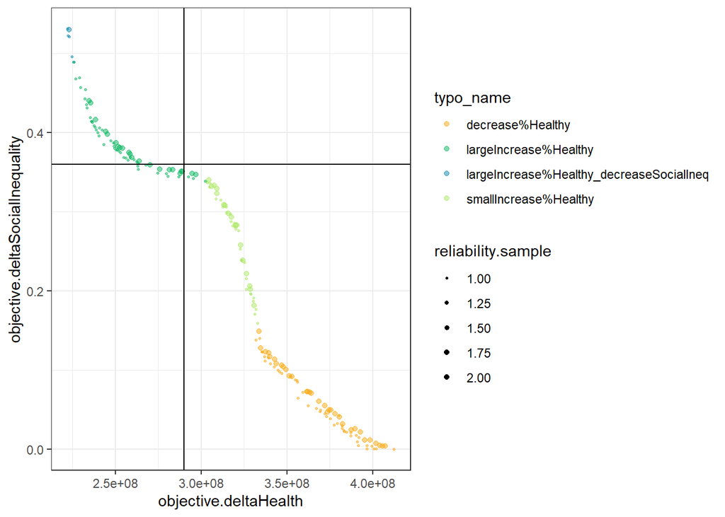

```r
pareto$reliability.sample <- ifelse(pareto$evolution.samples>5, 2,1)
pareto$objective.deltaHealth <- as.numeric(gsub(",","",pareto$objective.deltaHealth))

front <- ggplot(data=pareto, aes(x = objective.deltaHealth, y=objective.deltaSocialInequality))
front +
  geom_point(aes(group = typo_name, colour = typo_name,
                       size=reliability.sample)) +
  scale_size_continuous(range = c(0.5,1.5)) +
  scale_colour_manual(values = alpha(
    c("#faa911", #orange
      "#07b55e", #green
      "#1088b0", #blue
      "#aae860" #light green
      ), .5)) +
  geom_vline(xintercept = 290000000) +
  geom_hline(yintercept = 0.36) +
  theme_bw()
```

Distribution of parameter values along the Pareto front (Appendix 6)

```r
pareto$id <- rownames(pareto)
colnames(pareto)
```

```
##  [1] "evolution.generation"            "evolution.evaluated"
##  [3] "evolution.samples"               "maxProbaToSwitch"
##  [5] "constraintsStrength"             "inertiaCoefficient"
##  [7] "healthyDietReward"               "objective.deltaHealth"
##  [9] "objective.deltaSocialInequality" "X.Healthy_vs._2002"
## [11] "X.Healthy_vs._2008"              "socialIneq_vs._2002"
## [13] "typo"                            "typo_name"
## [15] "socialInequality"                "deltaSocialInequality"
## [17] "opinionMedian"                   "numberOfHealthy"
## [19] "deltaHealth"                     "reliability.sample"
## [21] "id"
```

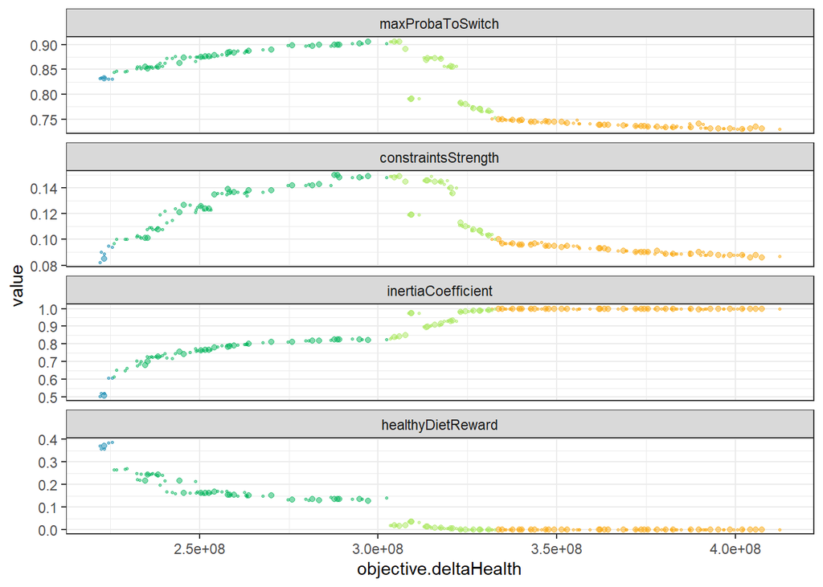

```r
pareto_long <- melt(pareto[,c("maxProbaToSwitch","constraintsStrength" ,
                              "inertiaCoefficient","healthyDietReward",
                              "objective.deltaSocialInequality", "objective.deltaHealth",
                              "typo_name", "reliability.sample")],
                    id.vars=c("objective.deltaSocialInequality", "objective.deltaHealth",
                              "typo_name", "reliability.sample"))

ggplot(pareto_long, aes(objective.deltaHealth, value)) +
  geom_point(aes(group = typo_name, colour = typo_name,
                 size=reliability.sample)) +
  scale_size_continuous(range = c(0.5,1.5)) + scale_colour_manual(values = alpha(
    c("#faa911", #orange
      "#07b55e", #green
      "#1088b0", #blue
      "#aae860" #light green
    ), .5)) +
  theme_bw() +  theme(legend.position="none") +
  facet_wrap(~variable, scales = "free_y", ncol = 1)
```

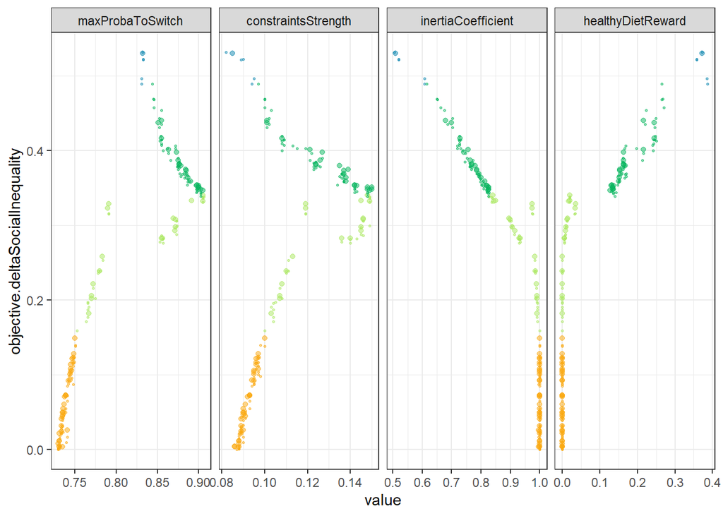

```r
ggplot(pareto_long, aes(value, objective.deltaSocialInequality)) +
  geom_point(aes(group = typo_name, colour = typo_name,
                 size=reliability.sample)) +
  scale_size_continuous(range = c(0.5,1.5)) + scale_colour_manual(values = alpha(
    c("#faa911", #orange
      "#07b55e", #green
      "#1088b0", #blue
      "#aae860" #light green
    ), .5)) +
  theme_bw()  +  theme(legend.position="none")+
  facet_wrap(~variable, scales = "free_x", nrow = 1)
```

# Results (section 4)

### Social inequalities in healthy behaviour for the 5 scenarios (Figure 5)

Importing simulation results

```r
sim <- read.csv2("data/results-25042022-10000replications.csv", sep=",", dec=".")
sim$Scenario <- ifelse(sim$numOfScenario == 1, "1A: Random residence / no move",
                       ifelse(sim$numOfScenario == 2, "1B: Random residence / random moves",
                              ifelse(sim$numOfScenario == 3, "2A: Observed residence / no move",
                                     ifelse(sim$numOfScenario == 4, "2B: Observed residence / random moves",
                                            "2C: Observed residence / observed moves"))))
head(sim)
```

```
##   constraintsStrength erreygersE healthyDietReward inertiaCoefficient
## 1            0.128944 0.03559005          0.153103          0.8195314
## 2            0.128944 0.03589710          0.153103          0.8195314
## 3            0.128944 0.03558682          0.153103          0.8195314
## 4            0.128944 0.03597858          0.153103          0.8195314
## 5            0.128944 0.03580784          0.153103          0.8195314
## 6            0.128944 0.03594730          0.153103          0.8195314
##   maxProbaToSwitch numOfScenario numberOfHealthy          seed socialInequality
## 1        0.8904704             1         1187441  5.241114e+18         1.384503
## 2        0.8904704             1         1188705  8.182251e+18         1.389434
## 3        0.8904704             1         1188073 -5.732413e+18         1.383992
## 4        0.8904704             1         1190153 -9.124344e+18         1.388518
## 5        0.8904704             1         1189071 -3.952058e+18         1.385801
## 6        0.8904704             1         1191965 -7.961473e+18         1.385447
##   openmole.experiment                       Scenario
## 1               20103 1A: Random residence / no move
## 2               20099 1A: Random residence / no move
## 3               20107 1A: Random residence / no move
## 4               20105 1A: Random residence / no move
## 5               20101 1A: Random residence / no move
## 6               20285 1A: Random residence / no move
```

Distribution of simulated values of EducIneqIndex (EII) for the five space-time scenarios (10 000 replications per scenario) (figure 5)

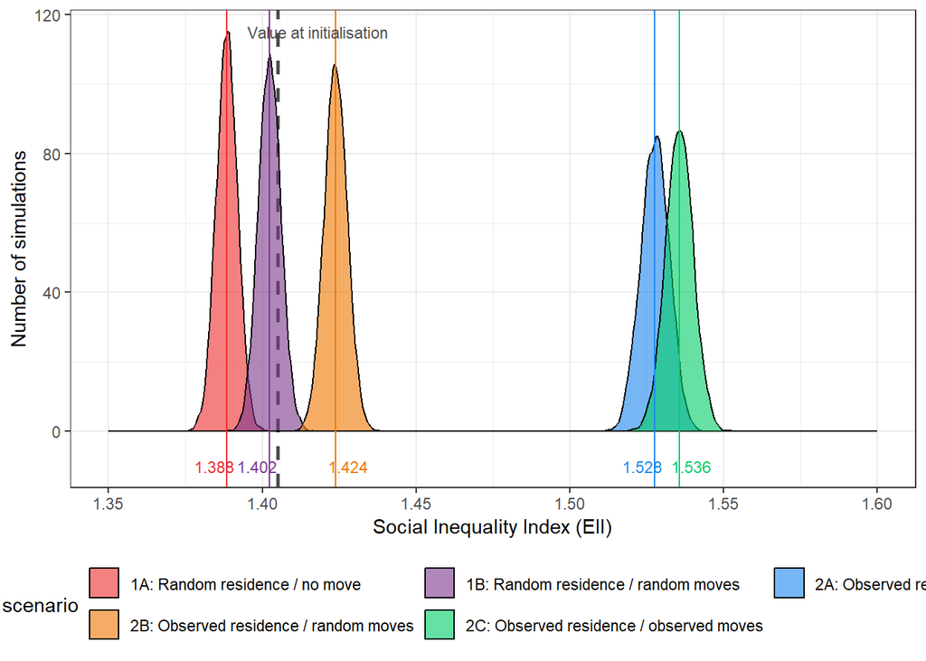

```r
mean_1A <- mean(sim[sim$numOfScenario == 1,"socialInequality"])
mean_1B <- mean(sim[sim$numOfScenario == 2,"socialInequality"])
mean_2A <- mean(sim[sim$numOfScenario == 3,"socialInequality"])
mean_2B <- mean(sim[sim$numOfScenario == 4,"socialInequality"])
mean_2C <- mean(sim[sim$numOfScenario == 5,"socialInequality"])

sim %>%
  ggplot( aes(x=socialInequality, group=Scenario, fill=Scenario)) +
  geom_vline(xintercept=1.405, size=1, color="grey30", linetype = "dashed") +
  geom_density(alpha=0.6) +
  scale_fill_manual(values=c("firebrick2", "mediumorchid4", "dodgerblue2", "darkorange2", "springgreen3"))+
  theme_bw() +
  geom_vline(xintercept=mean_1A, size=0.4, color="firebrick2") +
  geom_vline(xintercept=mean_1B, size=0.4, color="mediumorchid4") +
  geom_vline(xintercept=mean_2A, size=0.4, color="dodgerblue2") +
  geom_vline(xintercept=mean_2B, size=0.4, color="darkorange2") +
  geom_vline(xintercept=mean_2C, size=0.4, color="springgreen3") +
  annotate("text", x=mean_1A - 0.004, y= -10, size=3, label=round(mean_1A,3), color="firebrick2") +
  annotate("text", x=mean_1B - 0.004 , y= -10, size=3, label=round(mean_1B,3), color="mediumorchid4") +
  annotate("text", x=mean_2A - 0.004 , y= -10, size=3, label=round(mean_2A,3), color="dodgerblue2") +
  annotate("text", x=mean_2B + 0.004 , y= -10, size=3, label=round(mean_2B,3), color="darkorange2") +
  annotate("text", x=mean_2C + 0.004, y= -10, size=3, label=round(mean_2C,3), color="springgreen3") +
  annotate("text", x=1.405 + 0.013, y= 115, size=3, label="Value at initialisation", color="grey30") +
  xlab("Social Inequality Index (EII)") +
  ylab("Number of simulations") +
  xlim(1.35,1.6) +
  guides(fill=guide_legend(title="Type of scenario",nrow=2,byrow=TRUE)) +
  theme(legend.position = "bottom")
```

### Sensitivity to random moves (Figure 6)

```r
random_moves <- read.csv("data/random_moves.csv")
head(random_moves)
```

```
##   erreygersE numberOfHealthy openmole.experiment randomMoveRatio          seed
## 1 0.03682734         1150567                 706               1 -7.331534e+18
## 2 0.03661155         1158102                 700               1 -3.395561e+18
## 3 0.03655777         1151786                 681               1  8.946059e+18
## 4 0.03665694         1151391                 663               1  3.690077e+17
## 5 0.03652460         1151135                 672               1  3.693937e+18
## 6 0.03671739         1153199                 675               1  4.750891e+18
##   socialInequality
## 1         1.429419
## 2         1.418540
## 3         1.422918
## 4         1.423681
## 5         1.421879
## 6         1.424769
```

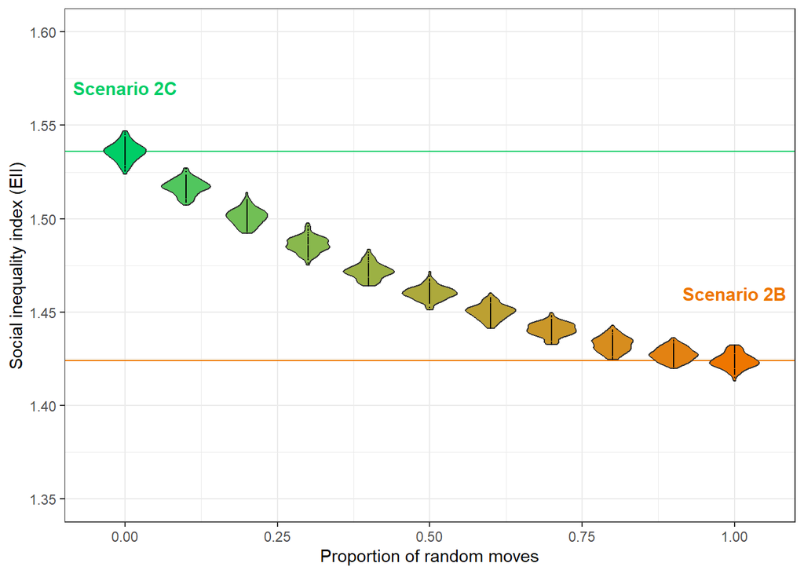

```r
annotation <- data.frame(
   x = c(0,1),
   y = c(1.57,1.46),
   label = c("Scenario 2C", "Scenario 2B")
)


ggplot(random_moves, aes(x=randomMoveRatio, y=socialInequality)) +
    geom_hline(yintercept = 1.424, color = "darkorange2") +
  geom_hline(yintercept = 1.536, color = "springgreen3") +
  geom_violin(aes(group=randomMoveRatio, fill=randomMoveRatio)) +
  geom_point(size=0.05) +
  scale_fill_gradient(
    low = "springgreen3",
    high = "darkorange2"
    ) +
  geom_text(data=annotation, aes(x=x, y=y, label=label),
            colour = c("springgreen3","darkorange2"),
           size=4 , angle=0, fontface="bold") +
 ylim(1.35,1.6) +
  guides(fill="none") +
  xlab("Proportion of random moves") +
  ylab("Social inequality index (EII)")+
  theme_bw()
```

### Proportions of healthy agents for the 5 scenarios (Figure 7)

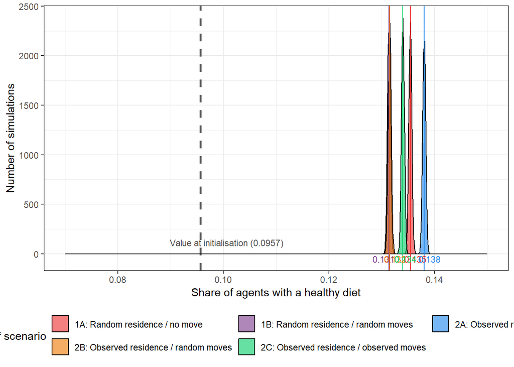

```r
mean_1A <- mean(sim[sim$numOfScenario == 1,"numberOfHealthy"]/8778898)
mean_1B <- mean(sim[sim$numOfScenario == 2,"numberOfHealthy"]/8778898)
mean_2A <- mean(sim[sim$numOfScenario == 3,"numberOfHealthy"]/8778898)
mean_2B <- mean(sim[sim$numOfScenario == 4,"numberOfHealthy"]/8778898)
mean_2C <- mean(sim[sim$numOfScenario == 5,"numberOfHealthy"]/8778898)

sim %>%
  ggplot( aes(x=numberOfHealthy/8778898, group=Scenario, fill=Scenario)) +
  geom_vline(xintercept=0.0957, size=1, color="grey30", linetype = "dashed") +
  geom_density(alpha=0.6) +
  scale_fill_manual(values=c("firebrick2", "mediumorchid4", "dodgerblue2", "darkorange2", "springgreen3"))+
  theme_bw() +
  geom_vline(xintercept=mean_1A, size=0.4, color="firebrick2") +
  geom_vline(xintercept=mean_1B, size=0.4, color="mediumorchid4") +
  geom_vline(xintercept=mean_2A, size=0.4, color="dodgerblue2") +
  geom_vline(xintercept=mean_2B, size=0.4, color="darkorange2") +
  geom_vline(xintercept=mean_2C, size=0.4, color="springgreen3") +
  annotate("text", x=mean_1A + 0.001, y= -50, size=3, label=round(mean_1A,3), color="firebrick2") +
  annotate("text", x=mean_1B - 0.001 , y= -50, size=3, label=round(mean_1B,3), color="mediumorchid4") +
  annotate("text", x=mean_2A + 0.001 , y= -50, size=3, label=round(mean_2A,3), color="dodgerblue2") +
  annotate("text", x=mean_2B + 0.001 , y= -50, size=3, label=round(mean_2B,3), color="darkorange2") +
  annotate("text", x=mean_2C + 0.0005, y= -50, size=3, label=round(mean_2C,3), color="springgreen3") +
  annotate("text", x=0.0957 + 0.005, y= 115, size=3, label="Value at initialisation (0.0957)", color="grey30") +
  xlab("Share of agents with a healthy diet") +
  ylab("Number of simulations") +
  xlim(0.07,0.15) +
  guides(fill=guide_legend(title="Type of scenario",nrow=2,byrow=TRUE)) +
  theme(legend.position = "bottom")
```

### Map of healthy agents in their night cells for the 5 scenarios (Figure 8)

```r
s0r <- st_read( "data/results_HigherProp_Scenario1_RandomPop_NoMove_42.gpkg",
              layer="Initial_0", quiet = TRUE)
s0o <- st_read( "data/results_HigherProp_Scenario5_ObservedPop_ObservedMove_42.gpkg",
               layer="Initial_0", quiet = TRUE)

s1A <- st_read( "data/results_HigherProp_Scenario1_RandomPop_NoMove_42.gpkg",
               layer="Final", quiet = TRUE)
s1B <- st_read( "data/results_HigherProp_Scenario2_RandomPop_RandomMove_42.gpkg",
               layer="Final", quiet = TRUE)

s2A <- st_read( "data/results_HigherProp_Scenario3_ObservedPop_NoMove_42.gpkg",
               layer="Final", quiet = TRUE)
s2B <- st_read( "data/results_HigherProp_Scenario4_ObservedPop_RandomMove_42.gpkg",
               layer="Final", quiet = TRUE)
s2C <- st_read( "data/results_HigherProp_Scenario5_ObservedPop_ObservedMove_42.gpkg",
               layer="Final", quiet = TRUE)

bks <- c(0, 0.1, 0.125, 0.15, 0.175, Inf)
```

Maps

Initial Random

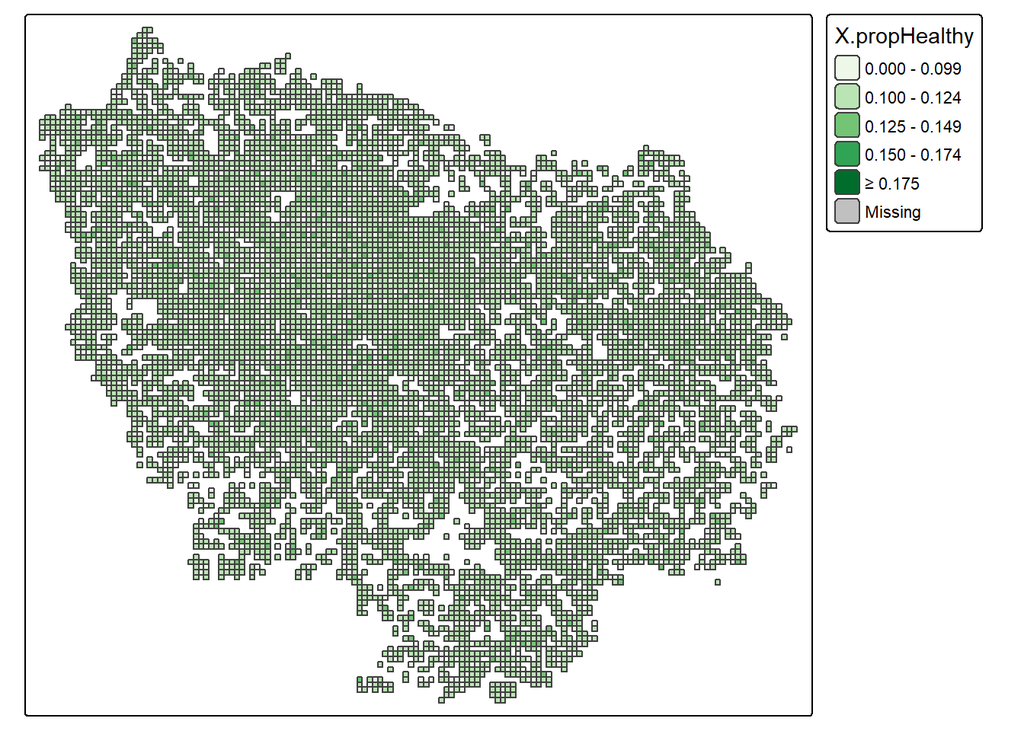

```r
tm_shape(s0r) + tm_fill(col="X.propHealthy", style="fixed",
                       breaks = bks, palette="Greens") +
  tm_legend(outside=TRUE)
```

Initial Observed

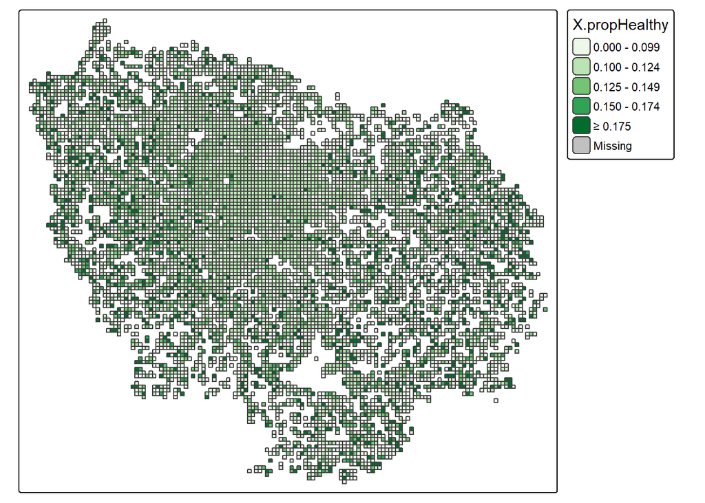

```r
tm_shape(s0o) + tm_fill(col="X.propHealthy", style="fixed",
                       breaks = bks, palette="Greens") +
  tm_legend(outside=TRUE)
```

Scenario 1A

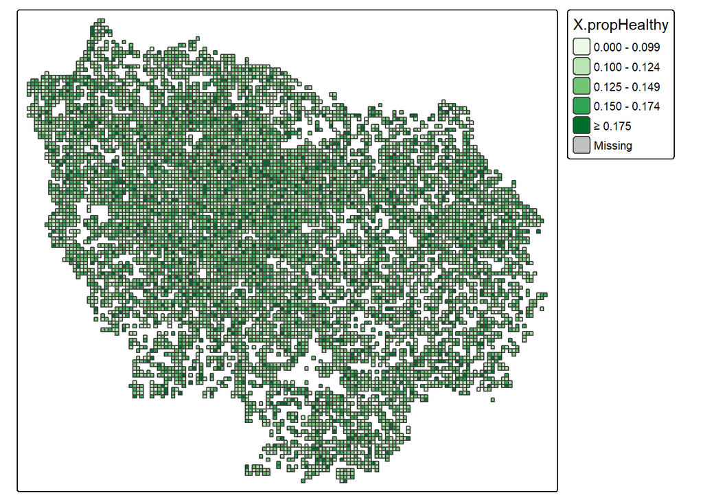

```r
tm_shape(s1A) + tm_fill(col="X.propHealthy", style="fixed",
                       breaks = bks, palette="Greens") +
  tm_legend(outside=TRUE)
```

Scenario 1B

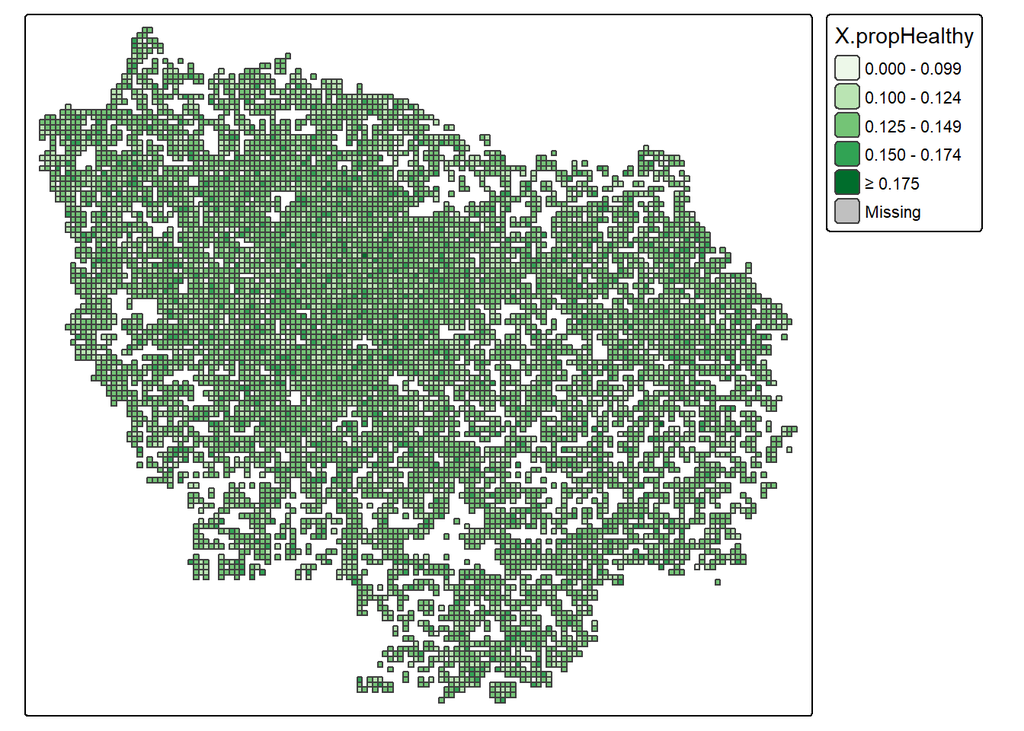

```r
tm_shape(s1B) + tm_fill(col="X.propHealthy", style="fixed",
                        breaks = bks, palette="Greens") +
  tm_legend(outside=TRUE)
```

Scenario 2A

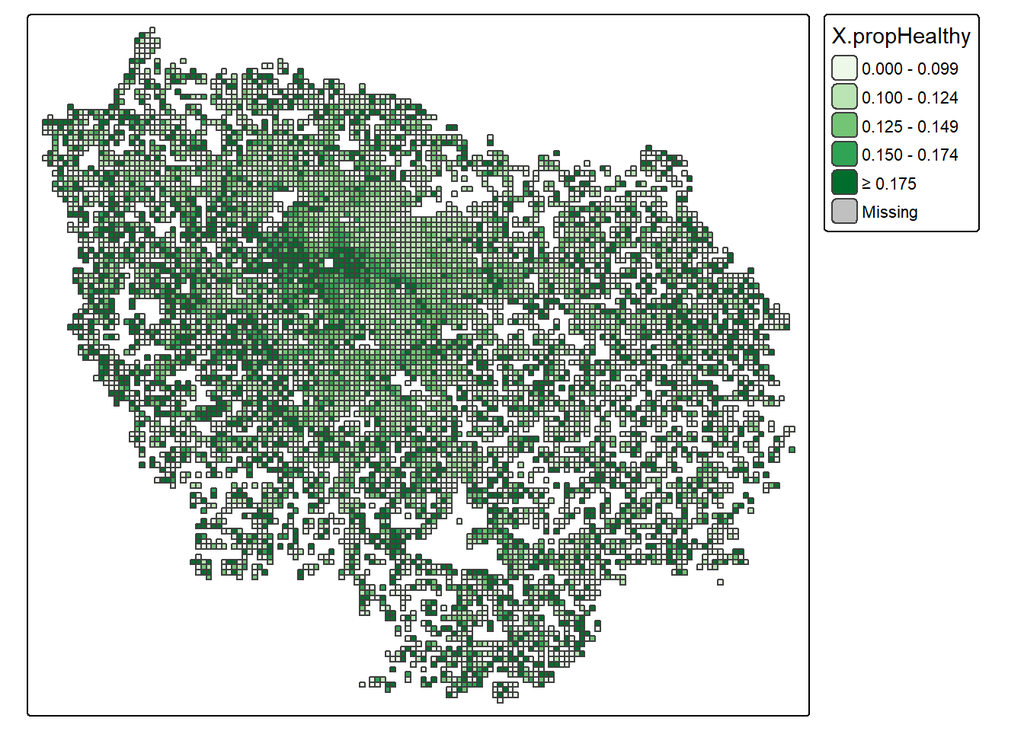

```r
tm_shape(s2A) + tm_fill(col="X.propHealthy", style="fixed",
                        breaks = bks, palette="Greens") +
  tm_legend(outside=TRUE)
```

Scenario 2B

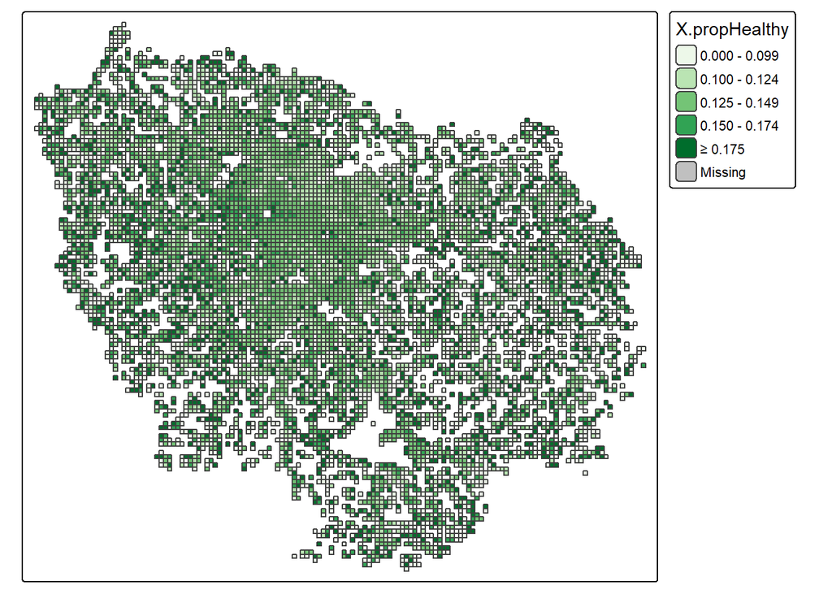

```r
tm_shape(s2B) + tm_fill(col="X.propHealthy", style="fixed",
                        breaks = bks, palette="Greens") +
  tm_legend(outside=TRUE)
```

Scenario 2C

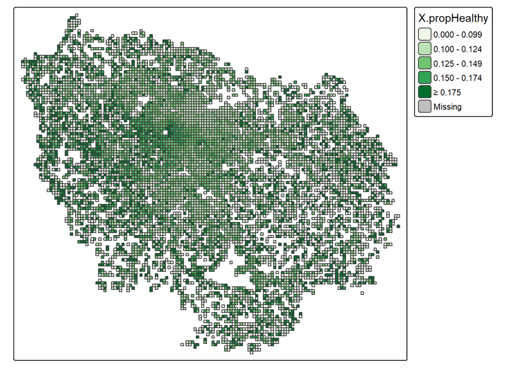

```r
tm_shape(s2C) + tm_fill(col="X.propHealthy", style="fixed",
                        breaks = bks, palette="Greens") +
  tm_legend(outside=TRUE)
```

### Duncan Dissimilarity Index - night cells (add in Figure 8)

```r
duncan <- data.frame(matrix(ncol = 2, nrow=7))
colnames(duncan) <- c("type", "Duncan" )

dfs0r<- s0r %>% st_drop_geometry()
duncan[1,1] <- "s0r_night"
duncan[1,2]<- ISDuncan(dfs0r[,3:4]) [1]

dfs0o<- s0o %>% st_drop_geometry()
duncan[2,1] <- "s0o_night"
duncan[2,2]<- ISDuncan(dfs0o[,3:4]) [1]


dfs1A<- s1A %>% st_drop_geometry()
duncan[3,1] <- "s1A_final_night"
duncan[3,2]<- ISDuncan(dfs1A[,3:4]) [1]

dfs1B<- s1B %>% st_drop_geometry()
duncan[4,1] <- "s1B_final_night"
duncan[4,2]<- ISDuncan(dfs1B[,3:4]) [1]


dfs2A<- s2A %>% st_drop_geometry()
duncan[5,1] <- "s2A_final_night"
duncan[5,2]<- ISDuncan(dfs2A[,3:4]) [1]

dfs2B<- s2B %>% st_drop_geometry()
duncan[6,1] <- "s2B_final_night"
duncan[6,2]<- ISDuncan(dfs2B[,3:4]) [1]

dfs2C<- s2C %>% st_drop_geometry()
duncan[7,1] <- "s2C_final_night"
duncan[7,2]<- ISDuncan(dfs2C[,3:4]) [1]

duncan_round <- duncan %>% mutate(across(starts_with("Duncan"), round, 3))

duncan_round
```

```
##              type Duncan
## 1       s0r_night  0.040
## 2       s0o_night  0.038
## 3 s1A_final_night  0.084
## 4 s1B_final_night  0.043
## 5 s2A_final_night  0.098
## 6 s2B_final_night  0.045
## 7 s2C_final_night  0.063
```

### Moran’s index of spatial autocorrelation - night cells (add in Figure 8)

```r
moran <- data.frame(matrix(ncol = 3, nrow=7))
colnames(moran) <- c("type", "IMoran" , "pvalueMoran")

nbs0r <- poly2nb(s0r, queen=TRUE)
lws0r  <- nb2listw(nbs0r, style="W", zero.policy=TRUE)
moran[1,1] <- "s0r_night"
moran[1,2] <- moran.test(s0r$X.propHealthy, lws0r, zero.policy=TRUE, alternative="greater") [3]
moran[1,3] <- moran.test(s0r$X.propHealthy, lws0r, zero.policy=TRUE, alternative="greater") [2]

nbs0o <- poly2nb(s0o, queen=TRUE)
lws0o  <- nb2listw(nbs0o, style="W", zero.policy=TRUE)
moran[4,1] <- "s0o_night"
moran[4,2] <- moran.test(s0o$X.propHealthy, lws0o, zero.policy=TRUE, alternative="greater") [3]
moran[4,3] <- moran.test(s0o$X.propHealthy, lws0o, zero.policy=TRUE, alternative="greater") [2]

nbs1A <- poly2nb(s1A, queen=TRUE)
lws1A  <- nb2listw(nbs1A, style="W", zero.policy=TRUE)
moran[2,1] <- "s1A_final_night"
moran[2,2] <- moran.test(s1A$X.propHealthy, lws1A, zero.policy=TRUE, alternative="greater") [3]
moran[2,3] <- moran.test(s1A$X.propHealthy, lws1A, zero.policy=TRUE, alternative="greater") [2]

nbs1B <- poly2nb(s1B, queen=TRUE)
lws1B  <- nb2listw(nbs1B, style="W", zero.policy=TRUE)
moran[3,1] <- "s1B_final_night"
moran[3,2] <- moran.test(s1B$X.propHealthy, lws1B, zero.policy=TRUE, alternative="greater") [3]
moran[3,3] <- moran.test(s1B$X.propHealthy, lws1B, zero.policy=TRUE, alternative="greater") [2]


nbs2A <- poly2nb(s2A, queen=TRUE)
lws2A  <- nb2listw(nbs2A, style="W", zero.policy=TRUE)
moran[5,1] <- "s2A_final_night"
moran[5,2] <- moran.test(s2A$X.propHealthy, lws2A, zero.policy=TRUE, alternative="greater") [3]
moran[5,3] <- moran.test(s2A$X.propHealthy, lws2A, zero.policy=TRUE, alternative="greater") [2]

nbs2B <- poly2nb(s2B, queen=TRUE)
lws2B  <- nb2listw(nbs2B, style="W", zero.policy=TRUE)
moran[6,1] <- "s2B_final_night"
moran[6,2] <- moran.test(s2B$X.propHealthy, lws2B, zero.policy=TRUE, alternative="greater") [3]
moran[6,3] <- moran.test(s2B$X.propHealthy, lws2B, zero.policy=TRUE, alternative="greater") [2]

nbs2C <- poly2nb(s2C, queen=TRUE)
lws2C  <- nb2listw(nbs2C, style="W", zero.policy=TRUE)
moran[7,1] <- "s2C_final_night"
moran[7,2] <- moran.test(s2C$X.propHealthy, lws2C, zero.policy=TRUE, alternative="greater") [3]
moran[7,3] <- moran.test(s2C$X.propHealthy, lws2C, zero.policy=TRUE, alternative="greater") [2]

moran_round <- moran %>% mutate(across(2:3, round, 3))

moran_round
```

```
##              type IMoran pvalueMoran
## 1       s0r_night  0.010       0.061
## 2 s1A_final_night  0.010       0.057
## 3 s1B_final_night  0.016       0.008
## 4       s0o_night  0.006       0.175
## 5 s2A_final_night  0.033       0.000
## 6 s2B_final_night  0.024       0.000
## 7 s2C_final_night  0.009       0.091
```

# Appendices (Supp. Material)

## Alternative measure of social inequality in health behaviour (Appendix 4)

Computation of rank-ordered inequality measure

```r
data_edu <- aggregate(data[,c("n_idf", "N_2002", "N_2008",
                              "h_idf_2002", "h_idf_2008",
                              "h_baro_2002", "h_baro_2008")],
                      by = list(data$Edu), FUN = sum)
colnames(data_edu)[1] <- "edu"
data_edu
```

```
##   edu   n_idf N_2002 N_2008 h_idf_2002 h_idf_2008 h_baro_2002 h_baro_2008
## 1   1 3800999   1030   1372     336079     359509         122         155
## 2   2 2946028    595   1135     279323     361858          57         132
## 3   3 2021871    471    797     223609     335409          44         110
```

```r
guido <- function(data_edu, year, sample){

  if(sample == "idf"){
    n <- sum(data_edu[,"n_idf"])
    n1 <- data_edu[data_edu$edu == 1,"n_idf"]
    n2 <- data_edu[data_edu$edu == 2,"n_idf"]
    n3 <- data_edu[data_edu$edu == 3,"n_idf"]
  } else {
    n <- sum(data_edu[,paste("N", year, sep="_")])
    n1 <- data_edu[data_edu$edu == 1,paste("N", year, sep="_")]
    n2 <- data_edu[data_edu$edu == 2,paste("N", year, sep="_")]
    n3 <- data_edu[data_edu$edu == 3,paste("N", year, sep="_")]
  }

  h1 <- data_edu[data_edu$edu == 1,paste("h", sample, year, sep="_")]
  h2 <- data_edu[data_edu$edu == 2,paste("h", sample, year, sep="_")]
  h3 <- data_edu[data_edu$edu == 3,paste("h", sample, year, sep="_")]

  t1 <- (1 - n2 - n3) / 2
  t2 <- (n1 - n3 + 1) / 2
  t3 <- (n1 + n2 + 1) / 2

  guido <- ( 8 / n^2 ) * (h1 * t1 + h2 * t2 + h3 * t3)
  return(guido)
}

guido(data_edu = data_edu, year = 2002, sample = "idf")
```

```
## [1] 0.01748087
```

```r
guido(data_edu = data_edu, year = 2008, sample = "idf")
```

```
## [1] 0.05830406
```

```r
guido(data_edu = data_edu, year = 2002, sample = "baro")
```

```
## [1] -0.02409715
```

```r
guido(data_edu = data_edu, year = 2008, sample = "baro")
```

```
## [1] 0.01927629
```

Density distribution of rank-order inequality index per scenario (Appendix 4)

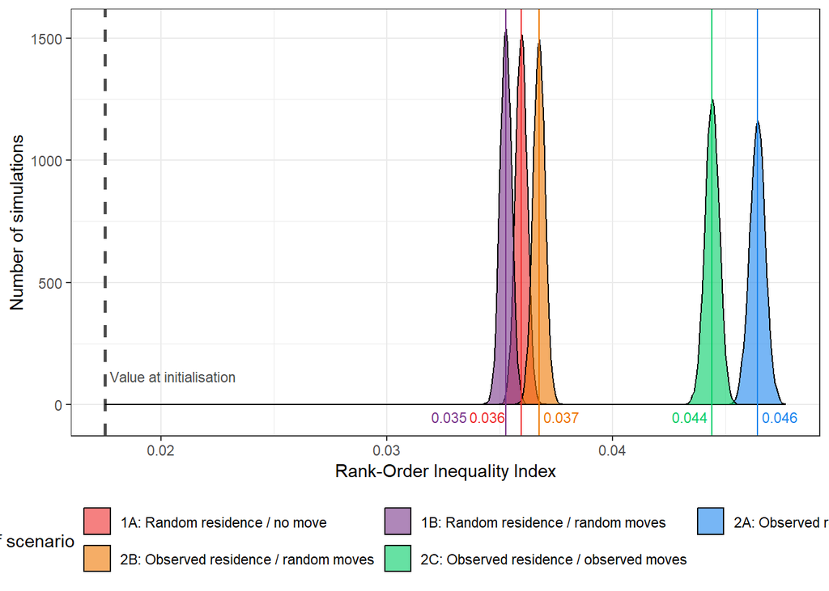

```r
mean_1A <- mean(sim[sim$numOfScenario == 1,"erreygersE"])
mean_1B <- mean(sim[sim$numOfScenario == 2,"erreygersE"])
mean_2A <- mean(sim[sim$numOfScenario == 3,"erreygersE"])
mean_2B <- mean(sim[sim$numOfScenario == 4,"erreygersE"])
mean_2C <- mean(sim[sim$numOfScenario == 5,"erreygersE"])

sim %>%
  ggplot( aes(x=erreygersE, group=Scenario, fill=Scenario)) +
  geom_vline(xintercept=0.0175, size=1, color="grey30", linetype = "dashed") +
  geom_density(alpha=0.6) +
  scale_fill_manual(values=c("firebrick2", "mediumorchid4", "dodgerblue2", "darkorange2", "springgreen3"))+
  theme_bw() +
  geom_vline(xintercept=mean_1A, size=0.4, color="firebrick2") +
  geom_vline(xintercept=mean_1B, size=0.4, color="mediumorchid4") +
  geom_vline(xintercept=mean_2A, size=0.4, color="dodgerblue2") +
  geom_vline(xintercept=mean_2B, size=0.4, color="darkorange2") +
  geom_vline(xintercept=mean_2C, size=0.4, color="springgreen3") +
  annotate("text", x=mean_1A - 0.0015, y= -50, size=3, label=round(mean_1A,3), color="firebrick2") +
  annotate("text", x=mean_1B - 0.0025 , y= -50, size=3, label=round(mean_1B,3), color="mediumorchid4") +
  annotate("text", x=mean_2A + 0.001 , y= -50, size=3, label=round(mean_2A,3), color="dodgerblue2") +
  annotate("text", x=mean_2B + 0.001 , y= -50, size=3, label=round(mean_2B,3), color="darkorange2") +
  annotate("text", x=mean_2C - 0.001, y= -50, size=3, label=round(mean_2C,3), color="springgreen3") +
  annotate("text", x= 0.0175 + 0.003, y= 115, size=3, label="Value at initialisation", color="grey30") +
  xlab("Rank-Order Inequality Index") +
  ylab("Number of simulations") +
  guides(fill=guide_legend(title="Type of scenario", nrow=2, byrow=TRUE)) +
  theme(legend.position = "bottom")
```

## Evolution in simulated values over the six series of three time slices (Appendix 8)

#### Part A & Part B

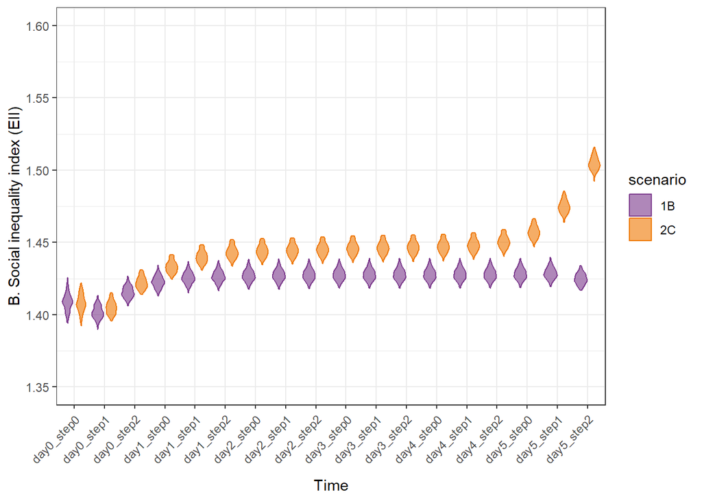

```r
phase <- read.csv("data/phase_48.csv")

long_table <- data.frame()
i <- 0
j <- 1
time <- data.frame(
  day = rep("day",18),
  nd = sort(rep(0:5,3)),
  step = rep("step",18),
  ns = rep(0:2,6)) |>
  mutate(time = paste0(day, nd, "_", step, ns)) |>
  select(time)

for(i in 1:nrow(phase)){
  nsenario <- phase[i, "numOfScenario"]
  EII <- t(
    str_split(
      str_replace(
        str_replace( phase[i, "socialInequality"] , c("\\["), ""),
        c("\\["), ""
      ),
      ",", simplify = T
    )
  )[1:18,]
  healthy <- t(
    str_split(
      str_replace(
        str_replace( phase[i, "numberOfHealthy"] , c("\\["), ""),
        c("\\["), ""
      ),
      ",", simplify = T
    )
  )[1:18,]


  long_table[j:(j+17),"time"] <- time
  long_table[j:(j+17),"scenario"] <- rep(nsenario, 18)
  long_table[j:(j+17),"socialInequality"] <- EII
  long_table[j:(j+17),"numberOfHealthy"] <- healthy

  j <- j+18

}

plot_table <- long_table |>
  mutate(prop_healthy = as.numeric(numberOfHealthy) / 8768898,
         EII = as.numeric(socialInequality),
         scenario = as.factor(ifelse(scenario == 2, "1B",
                                     ifelse(scenario == 5, "2C", NA))
         ),
         group = paste0(time, scenario)
  )

ggplot(plot_table,
       aes(x = time, y = EII,
           colour = scenario, fill = scenario)) +
  geom_violin(aes(group=group), alpha = 0.6) +
 # geom_point() +
  scale_colour_manual(values = c("mediumorchid4", "darkorange2")) +
 scale_fill_manual(values = c("mediumorchid4","darkorange2")) +
  xlab("Time") +
  ylab("B. Social inequality index (EII)")  +
  theme(legend.position = "bottom") +
  ylim(1.35,1.6) +
  theme_bw() +
  theme(axis.text.x = element_text(angle = 45, vjust = 0.9, hjust=1.0)) +
   theme(axis.text.x.bottom = element_text(margin=margin(t=0, r=0,b=10,l=0)))
```

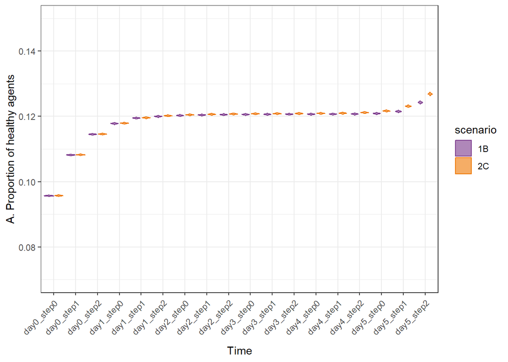

```r
ggplot(plot_table,
       aes(x = time, y = prop_healthy,
           colour = scenario, fill = scenario)) +
  geom_violin(aes(group=group), alpha = 0.6) +
 # geom_point() +
  scale_colour_manual(values = c("mediumorchid4", "darkorange2")) +
 scale_fill_manual(values = c("mediumorchid4","darkorange2")) +
  xlab("Time") +
  ylab("A. Proportion of healthy agents")  +
    theme(legend.position = "bottom") +
  ylim(0.07,0.15) +
  theme_bw() +
  theme(axis.text.x = element_text(angle = 45, vjust = 0.9, hjust=1.0)) +
   theme(axis.text.x.bottom = element_text(margin=margin(t=0, r=0,b=10,l=0)))
```

### Part C & Part D

Simulated proportion of healthy agents and simulated opinion across the 18 sociodemographic categories

```r
 specialRead <- function(x) {
   read_csv(file=x, col_names = TRUE, col_types= "nnnnnnnnnn")
 }

concatFiles <- function (base, folder){
   fullPath = paste(base,folder,sep="")
   list.files(path = fullPath, full.names = TRUE, pattern = "(\\d_\\d_\\d)") %>% lapply(specialRead) %>% bind_rows
}

recode <- function(x) {
  step_to_day <- c (
  '00' = 'day 0 step 0',
  '01' = 'day 0 step 1',
  '02' = 'day 0 step 2',
  '10' = 'day 1 step 0',
  '11' = 'day 1 step 1',
  '12' = 'day 1 step 2',
  '20' = 'day 2 step 0',
  '21' = 'day 2 step 1',
  '22' = 'day 2 step 2',
  '30' = 'day 3 step 0',
  '31' = 'day 3 step 1',
  '32' = 'day 3 step 2',
  '40' = 'day 4 step 0',
  '41' = 'day 4 step 1',
  '42' = 'day 4 step 2',
  '50' = 'day 5 step 0',
  '51' = 'day 5 step 1',
  '52' = 'day 5 step 2'
  )
  return(step_to_day[x])
}
```

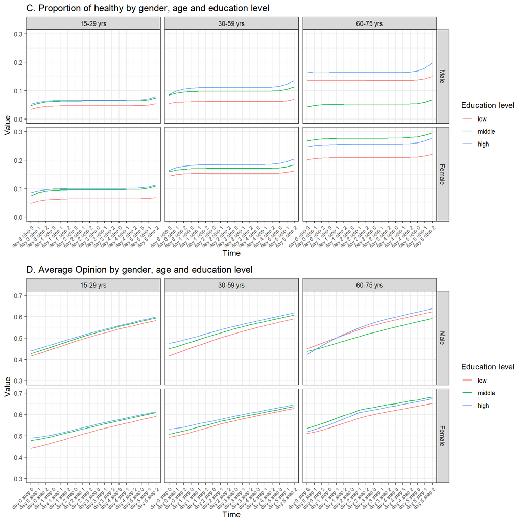

```r
sortie_sc5_higherprop <- concatFiles("data", "/HigherProp")
sortie_sc5_higherprop$propHealthy <- sortie_sc5_higherprop$healthy / sortie_sc5_higherprop$effective

sortieLong_sc5_hp <- gather(sortie_sc5_higherprop, facteur, valeur, c(propHealthy, avgOpinion) )
sortieLong_sc5_hp <- mutate(sortieLong_sc5_hp, "ds" = gsub(" ", "", paste(paste("[",paste(sortieLong_sc5_hp$day, sortieLong_sc5_hp$slice)),"]")))
sortieLong_sc5_hp <- mutate(sortieLong_sc5_hp, ds= recode(paste0(day, slice)))

age.l <- c("15-29 yrs", "30-59 yrs", "60-75 yrs")
names(age.l) <- c("1", "2", "3")

sex.l <- c("Male", "Female")
names(sex.l) <- c("1", "2")


p1 <- ggplot(data=sortieLong_sc5_hp %>% filter(facteur=="propHealthy"), aes(x=ds, y=valeur, group=educ, fill=educ, colour=as.character(educ)))
p1 <- p1 + scale_color_discrete(
    name = "Education level",
    labels = c("low", "middle", "high")
  )
p1 <- p1 + theme_bw() + theme(axis.text.x = element_text(angle = 45, vjust = 1, hjust=1, , size = 7))
p1 <- p1 + labs(title="C. Proportion of healthy by gender, age and education level", y = "Value", x = "Time")
p1 <- p1 + geom_line(size=0.5) + facet_grid( sex ~ age, labeller = labeller(sex = sex.l, age = age.l), scales = "fixed") #show.legend = FALSE
p1 <- p1 + coord_cartesian( ylim = c(0, 0.3))

p2 <- ggplot(data=sortieLong_sc5_hp %>% filter(facteur=="avgOpinion"), aes(x=ds, y=valeur, group=educ, fill=educ, colour=as.character(educ)))
p2 <- p2 + scale_color_discrete(
    name = "Education level",
    labels = c("low", "middle", "high")
  )
p2 <- p2 + theme_bw() + theme(axis.text.x = element_text(angle = 45, vjust = 1, hjust=1, size = 7))
p2 <- p2 + labs(title="D. Average Opinion by gender, age and education level", color = "Education level", y = "Value", x = "Time")
p2 <- p2 + geom_line(size=0.5) + facet_grid(sex ~ age, labeller = labeller(sex = sex.l, age = age.l), scales = "fixed") #show.legend = FALSE
p2 <- p2 + coord_cartesian( ylim = c(0.3, 0.7))

propHealtyAndOpinion_higherprop <- plot_grid(
  p1, p2,
  ncol = 1)

print(propHealtyAndOpinion_higherprop)
```

```r
##ggsave("out/propHealtyAndOpinion_higherprop.pdf")
```

# ———UNUSED———-

## Spatial distribution of agents with healthy behaviour - in day and evening cells

### In day cells

```r
s1A_day <- st_read( "data/results_HigherProp_Scenario1_RandomPop_NoMove_42.gpkg", quiet = TRUE,
                layer="Final_1")

s1B_day <- st_read( "data/results_HigherProp_Scenario2_RandomPop_RandomMove_42.gpkg", quiet = TRUE,
                layer="Final_1")

s2A_day <- st_read( "data/results_HigherProp_Scenario3_ObservedPop_NoMove_42.gpkg", quiet = TRUE,
                layer="Final_1")

s2B_day <- st_read( "data/results_HigherProp_Scenario4_ObservedPop_RandomMove_42.gpkg", quiet = TRUE,
                layer="Final_1")

s2C_day <- st_read( "data/results_HigherProp_Scenario5_ObservedPop_ObservedMove_42.gpkg", quiet = TRUE,
                layer="Final_1")
```

Duncan Dissimilarity Index

```r
duncan_day <- data.frame(matrix(ncol = 2, nrow=5))
colnames(duncan_day) <- c("type", "Duncan_dayCell" )

dfs1A_day<- s1A_day %>% st_drop_geometry()
duncan_day[1,1] <- "s1A_final_day"
duncan_day[1,2]<- ISDuncan(dfs1A_day[,3:4]) [1]

dfs1B_day<- s1B_day %>% st_drop_geometry()
duncan_day[2,1] <- "s1B_final_day"
duncan_day[2,2]<- ISDuncan(dfs1B_day[,3:4]) [1]

dfs2A_day<- s2A_day %>% st_drop_geometry()
duncan_day[3,1] <- "s2A_final_day"
duncan_day[3,2]<- ISDuncan(dfs2A_day[,3:4]) [1]

dfs2B_day<- s2B_day %>% st_drop_geometry()
duncan_day[4,1] <- "s2B_final_day"
duncan_day[4,2]<- ISDuncan(dfs2B_day[,3:4]) [1]

dfs2C_day<- s2C_day %>% st_drop_geometry()
duncan_day[5,1] <- "s2C_final_day"
duncan_day[5,2]<- ISDuncan(dfs2C_day[,3:4]) [1]

duncan_day <- duncan_day %>% mutate(across(starts_with("Duncan"), round, 3))
```

Moran’s index of spatial autocorrelation

```r
moran_day <- data.frame(matrix(ncol = 3, nrow=5))
colnames(moran_day) <- c("type", "IMoran_dayCell" , "pvalueMoran_dayCell")

nbs1A_day <- poly2nb(s1A_day, queen=TRUE)
lws1A_day  <- nb2listw(nbs1A_day, style="W", zero.policy=TRUE)
moran_day[1,1] <- "s1A_final_day"
moran_day[1,2] <- moran.test(s1A_day$X.propHealthy, lws1A_day, zero.policy=TRUE, alternative="greater") [3]
moran_day[1,3] <- moran.test(s1A_day$X.propHealthy, lws1A_day, zero.policy=TRUE, alternative="greater") [2]

nbs1B_day <- poly2nb(s1B_day, queen=TRUE)
lws1B_day  <- nb2listw(nbs1B_day, style="W", zero.policy=TRUE)
moran_day[2,1] <- "s1B_final_day"
moran_day[2,2] <- moran.test(s1B_day$X.propHealthy, lws1B_day, zero.policy=TRUE, alternative="greater") [3]
moran_day[2,3] <- moran.test(s1B_day$X.propHealthy, lws1B_day, zero.policy=TRUE, alternative="greater") [2]

nbs2A_day <- poly2nb(s2A_day, queen=TRUE)
lws2A_day  <- nb2listw(nbs2A_day, style="W", zero.policy=TRUE)
moran_day[3,1] <- "s2A_final_day"
moran_day[3,2] <- moran.test(s2A_day$X.propHealthy, lws2A_day, zero.policy=TRUE, alternative="greater") [3]
moran_day[3,3] <- moran.test(s2A_day$X.propHealthy, lws2A_day, zero.policy=TRUE, alternative="greater") [2]

nbs2B_day <- poly2nb(s2B_day, queen=TRUE)
lws2B_day  <- nb2listw(nbs2B_day, style="W", zero.policy=TRUE)
moran_day[4,1] <- "s2B_final_day"
moran_day[4,2] <- moran.test(s2B_day$X.propHealthy, lws2B_day, zero.policy=TRUE, alternative="greater") [3]
moran_day[4,3] <- moran.test(s2B_day$X.propHealthy, lws2B_day, zero.policy=TRUE, alternative="greater") [2]

nbs2C_day <- poly2nb(s2C_day, queen=TRUE)
lws2C_day  <- nb2listw(nbs2C_day, style="W", zero.policy=TRUE)
moran_day[5,1] <- "s2C_final_day"
moran_day[5,2] <- moran.test(s2C_day$X.propHealthy, lws2C_day, zero.policy=TRUE, alternative="greater") [3]
moran_day[5,3] <- moran.test(s2C_day$X.propHealthy, lws2C_day, zero.policy=TRUE, alternative="greater") [2]

moran_round_day <- moran_day %>% mutate(across(2:3, round, 3))
```

Combine Duncan and Moran files

```r
Duncan_moran_dayCell <- left_join(duncan_day, moran_round_day, by = "type")
Duncan_moran_dayCell
```

```
##            type Duncan_dayCell IMoran_dayCell pvalueMoran_dayCell
## 1 s1A_final_day          0.067          0.010               0.073
## 2 s1B_final_day          0.039         -0.014               0.983
## 3 s2A_final_day          0.078          0.030               0.000
## 4 s2B_final_day          0.038         -0.009               0.900
## 5 s2C_final_day          0.088          0.049               0.000
```

### In evening cells

```r
s1A_evening <- st_read( "data/results_HigherProp_Scenario1_RandomPop_NoMove_42.gpkg", quiet = TRUE,
                    layer="Final_2")

s1B_evening <- st_read( "data/results_HigherProp_Scenario2_RandomPop_RandomMove_42.gpkg", quiet = TRUE,
                    layer="Final_2")

s2A_evening <- st_read( "data/results_HigherProp_Scenario3_ObservedPop_NoMove_42.gpkg", quiet = TRUE,
                    layer="Final_2")

s2B_evening <- st_read( "data/results_HigherProp_Scenario4_ObservedPop_RandomMove_42.gpkg", quiet = TRUE,
                    layer="Final_2")

s2C_evening <- st_read( "data/results_HigherProp_Scenario5_ObservedPop_ObservedMove_42.gpkg", quiet = TRUE,
                    layer="Final_2")
```

Duncan Dissimilarity Index

```r
duncan_evening <- data.frame(matrix(ncol = 2, nrow=5))
colnames(duncan_evening) <- c("type", "Duncan_eveningCell" )


dfs1A_evening<- s1A_evening %>% st_drop_geometry()
duncan_evening[1,1] <- "s1A_final_evening"
duncan_evening[1,2]<- ISDuncan(dfs1A_evening[,3:4]) [1]

dfs1B_evening<- s1B_evening %>% st_drop_geometry()
duncan_evening[2,1] <- "s1B_final_evening"
duncan_evening[2,2]<- ISDuncan(dfs1B_evening[,3:4]) [1]

dfs2A_evening<- s2A_evening %>% st_drop_geometry()
duncan_evening[3,1] <- "s2A_final_evening"
duncan_evening[3,2]<- ISDuncan(dfs2A_evening[,3:4]) [1]

dfs2B_evening<- s2B_evening %>% st_drop_geometry()
duncan_evening[4,1] <- "s2B_final_evening"
duncan_evening[4,2]<- ISDuncan(dfs2B_evening[,3:4]) [1]

dfs2C_evening<- s2C_evening %>% st_drop_geometry()
duncan_evening[5,1] <- "s2C_final_evening"
duncan_evening[5,2]<- ISDuncan(dfs2C_evening[,3:4]) [1]

duncan_evening <- duncan_evening %>% mutate(across(starts_with("Duncan"), round, 3))
```

Moran’s index of spatial autocorrelation

```r
moran_evening <- data.frame(matrix(ncol = 3, nrow=5))
colnames(moran_evening) <- c("type", "IMoran_eveningCell" , "pvalueMoran_eveningCell")

nbs1A_evening <- poly2nb(s1A_evening, queen=TRUE)
lws1A_evening  <- nb2listw(nbs1A_evening, style="W", zero.policy=TRUE)
moran_evening[1,1] <- "s1A_final_evening"
moran_evening[1,2] <- moran.test(s1A_evening$X.propHealthy, lws1A_evening, zero.policy=TRUE, alternative="greater") [3]
moran_evening[1,3] <- moran.test(s1A_evening$X.propHealthy, lws1A_evening, zero.policy=TRUE, alternative="greater") [2]

nbs1B_evening <- poly2nb(s1B_evening, queen=TRUE)
lws1B_evening  <- nb2listw(nbs1B_evening, style="W", zero.policy=TRUE)
moran_evening[2,1] <- "s1B_final_evening"
moran_evening[2,2] <- moran.test(s1B_evening$X.propHealthy, lws1B_evening, zero.policy=TRUE, alternative="greater") [3]
moran_evening[2,3] <- moran.test(s1B_evening$X.propHealthy, lws1B_evening, zero.policy=TRUE, alternative="greater") [2]

nbs2A_evening <- poly2nb(s2A_evening, queen=TRUE)
lws2A_evening  <- nb2listw(nbs2A_evening, style="W", zero.policy=TRUE)
moran_evening[3,1] <- "s2A_final_evening"
moran_evening[3,2] <- moran.test(s2A_evening$X.propHealthy, lws2A_evening, zero.policy=TRUE, alternative="greater") [3]
moran_evening[3,3] <- moran.test(s2A_evening$X.propHealthy, lws2A_evening, zero.policy=TRUE, alternative="greater") [2]

nbs2B_evening <- poly2nb(s2B_evening, queen=TRUE)
lws2B_evening  <- nb2listw(nbs2B_evening, style="W", zero.policy=TRUE)
moran_evening[4,1] <- "s2B_final_evening"
moran_evening[4,2] <- moran.test(s2B_evening$X.propHealthy, lws2B_evening, zero.policy=TRUE, alternative="greater") [3]
moran_evening[4,3] <- moran.test(s2B_evening$X.propHealthy, lws2B_evening, zero.policy=TRUE, alternative="greater") [2]

nbs2C_evening <- poly2nb(s2C_evening, queen=TRUE)
lws2C_evening  <- nb2listw(nbs2C_evening, style="W", zero.policy=TRUE)
moran_evening[5,1] <- "s2C_final_evening"
moran_evening[5,2] <- moran.test(s2C_evening$X.propHealthy, lws2C_evening, zero.policy=TRUE, alternative="greater") [3]
moran_evening[5,3] <- moran.test(s2C_evening$X.propHealthy, lws2C_evening, zero.policy=TRUE, alternative="greater") [2]

moran_round_evening <- moran_evening %>% mutate(across(2:3, round, 3))
```

Combine Duncan and Moran files

```r
Duncan_moran_eveningCell <- left_join(duncan_evening, moran_round_evening, by = "type")
Duncan_moran_eveningCell
```

```
##                type Duncan_eveningCell IMoran_eveningCell
## 1 s1A_final_evening              0.084              0.010
## 2 s1B_final_evening              0.039             -0.005
## 3 s2A_final_evening              0.098              0.033
## 4 s2B_final_evening              0.038              0.000
## 5 s2C_final_evening              0.089              0.061
##   pvalueMoran_eveningCell
## 1                   0.057
## 2                   0.769
## 3                   0.000
## 4                   0.472
## 5                   0.000
```